# Final Presentation

Ben Whitehead

Thursday, December 02, 2021 @ 12:11 PM

## Libraries Used

```r
library(readr)
library(tidyverse)
library(lubridate)
library(openxlsx)
library(readxl)
library(jsonlite)
```

## Billionaire Data Set

### What my plot says.

I decided to do a scatter plot with three different variables: x being the combined worth of Billionaires in that Industry, the y being the total number of Billionaires in that Industry, and the color representing the Industry that is being represented. I used a log10 scale on the total worth, because the extreme outlier value in the Technology Billionaires made the data hard to see.

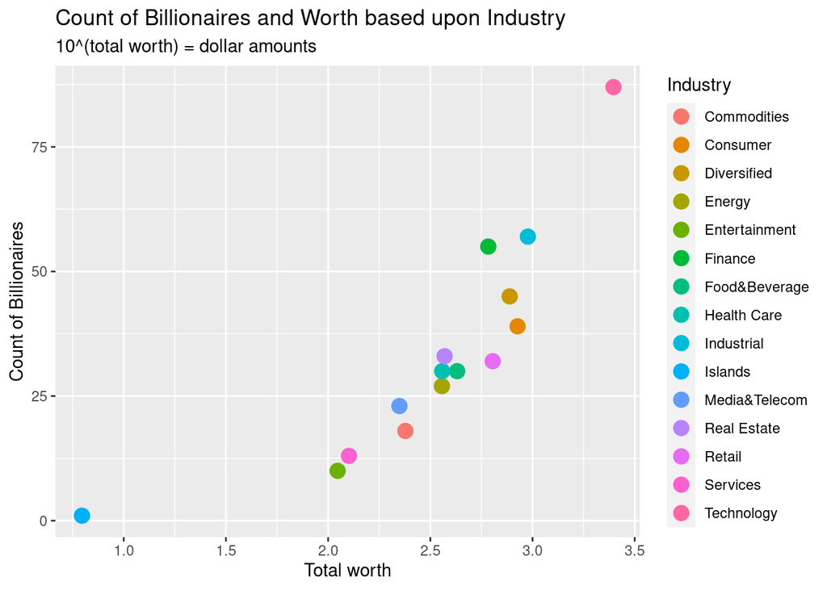

```r
billionaires <- read_csv("~/git_repositories/STT2860project2/dataraw/billionaires_2021_10_31.csv")

billionaires %>%
  select(Industry, Total_Net_Worth_Bil) %>%
  group_by(Industry) %>%
  summarize(totalbillions = sum(Total_Net_Worth_Bil), totalPeople = n()) %>%
  ggplot(aes(x = log10(totalbillions), y = totalPeople, color = Industry)) +
  geom_point(size = 4) +
  labs(title = "Count of Billionaires and Worth based upon Industry",
       x = "Total worth",
       y = "Count of Billionaires",
       subtitle = "10^(total worth) = dollar amounts")
```

## Real World Data Wrangling

### Employee hours for audit

My second part is an example of using the skills we have learned throughout this course and applying them to a real world problem. In this case, I was asked to submit weekly hours for an employee, and to use the governments preferred format of the weeks running from Sunday through Saturday, by weekly amount. In this case, we use Monday through Sunday and we run our payroll every two weeks, so any of our existing data would be useless to transpose. When I started viewing the time clock options, I noticed that I could download a csv file, so I decided to put my new skills to work.  
First I want to show what the original data looked like. Second, I show what the data looked like after skipping the first two rows, going 103 max lines and then separating the data by “,,”. Next, I get rid of the unnecessary columns, and mutate the hourly data to read in correctly, in order to perform the other calculations. I used epiweek, instead of isoweek, as this is the correct format for the governments week of Sunday through Saturday. Then I grouped by year and then week and lastly Position, as this would show both positions that this person works. When I summed the TotalHrs, it came out as seconds, so I needed to convert it to hours format. At last, I wrote the file back out as an excel file, so that we could submit it.

```r
Job_test <- read_csv("~/personal/Job-Punchcard-ReportNovember-29-2021-91144-am.csv")
Job_test
```

```
# A tibble: 114 × 2
   `Job Punchcard Report generated November 29 … `Period: June 20 2020 to March…
   <chr>                                         <chr>
 1 Employee: removed to protect the innocent     <NA>
 2 Date/Time In                                  Date/Time Out,Hours,Type,Job,
 3 9:54:25 am June 21 2020                       5:01:04 pm June 21 2020,07:06:…
 4 9:53:39 am June 23 2020                       4:42:09 pm June 23 2020,06:48:…
 5 9:55:23 am June 24 2020                       5:04:09 pm June 24 2020,07:09:…
 6 10:07:52 am June 25 2020                      5:39:18 pm June 25 2020,07:31:…
 7 9:53:52 am June 26 2020                       4:49:27 pm June 26 2020,06:55:…
 8 9:54:50 am June 27 2020                       5:46:59 pm June 27 2020,07:52:…
 9 9:54:27 am June 29 2020                       5:06:28 pm June 29 2020,07:12:…
10 9:51:57 am July 1 2020                        3:32:38 pm July 1 2020,05:40:4…
# … with 104 more rows
```

```r
Job_test_2 <- read_csv("~/personal/Job-Punchcard-ReportNovember-29-2021-91144-am.csv",
                       skip = 2, n_max = 103, quote = ",,",
                       col_names = c("TimeIn", "TimeOut",
                                     "TotalHrs", "4",
                                     "Position", "6",
                                     "7", "8", "9",
                                     "10", "11"))
Job_test_2
```

```
# A tibble: 102 × 13
   TimeIn TimeOut TotalHrs `4`   Position `6`   `7`   `8`   `9`   `10`     `11`
   <chr>  <chr>   <time>   <lgl> <chr>    <lgl> <lgl> <chr> <chr> <time>   <lgl>
 1 9:54:… 5:01:0… 07:06:36 NA    2 Wait/… NA    NA    :53:… 4:42… 06:48:36 NA
 2 9:55:… 5:04:0… 07:09:00 NA    2 Wait/… NA    NA    <NA>  <NA>        NA NA
 3 10:07… 5:39:1… 07:31:12 NA    2 Wait/… NA    NA    <NA>  <NA>        NA NA
 4 9:53:… 4:49:2… 06:55:48 NA    2 Wait/… NA    NA    <NA>  <NA>        NA NA
 5 9:54:… 5:46:5… 07:52:12 NA    2 Wait/… NA    NA    <NA>  <NA>        NA NA
 6 9:54:… 5:06:2… 07:12:00 NA    2 Wait/… NA    NA    <NA>  <NA>        NA NA
 7 9:51:… 3:32:3… 05:40:48 NA    2 Wait/… NA    NA    <NA>  <NA>        NA NA
 8 4:35:… 9:10:1… 04:34:48 NA    2 Wait/… NA    NA    <NA>  <NA>        NA NA
 9 9:50:… 4:36:3… 06:45:36 NA    2 Wait/… NA    NA    <NA>  <NA>        NA NA
10 9:56:… 4:56:3… 07:00:00 NA    2 Wait/… NA    NA    <NA>  <NA>        NA NA
# … with 92 more rows, and 2 more variables: X12 <chr>, X13 <lgl>
```

```r
Job_test_3 <- read_csv("~/personal/Job-Punchcard-ReportNovember-29-2021-91144-am.csv",
                       skip = 2,
                       n_max = 103,
                       quote = ",,",
                       col_names = c("TimeIn", "TimeOut",
                                     "TotalHrs", "4",
                                     "Position", "6",
                                     "7", "8", "9",
                                     "10", "11")) %>%
              select(TimeIn, TimeOut, TotalHrs, Position) %>%
              mutate(TimeIn = parse_date_time(TimeIn, "%I:%M:%S %p %b %d %Y"),
                     TimeOut = parse_date_time(TimeOut, "%I:%M:%S %p %b %d %Y"),
                     week = epiweek(TimeIn),
                     year = year(TimeIn)) %>%
              group_by(year, week, Position) %>%
              summarize(hours = seconds_to_period(sum(TotalHrs)))

Job_test_3
```

```
# A tibble: 39 × 4
# Groups:   year, week [36]
    year  week Position                 hours
   <dbl> <dbl> <chr>                    <Period>
 1  2020    26 2 Wait/Server            1d 12H 34M 48S
 2  2020    27 2 Wait/Server            1d 7H 13M 12S
 3  2020    28 2 Wait/Server            20H 45M 36S
 4  2020    29 2 Wait/Server            13H 49M 48S
 5  2020    30 2 Wait/Server            13H 33M 0S
 6  2020    31 1 Kitchen/Dish/Host/Expo 1H 13M 48S
 7  2020    31 2 Wait/Server            12H 59M 24S
 8  2020    32 1 Kitchen/Dish/Host/Expo 1H 31M 48S
 9  2020    32 2 Wait/Server            20H 46M 12S
10  2020    33 2 Wait/Server            14H 36M 0S
# … with 29 more rows
```

```r
# write.xlsx(Job_test_3, file = "Job.xlsx")
```